# ProPELL Survey Codebook

### Mean score of Norms items

**Overview**

- **Variable Stem: `tpbn`**
- **Time Points:** m1, m2, m3
- **Reference:** González et al. (2012)

**Details**

**Items**

| Variable | Scale | Prompt |
| --- | --- | --- |
| tpbn01 | Injunctive | Most people who are important to me want me to exercise regularly. |
| tpbn02 | Injunctive | Most people who are important to me think that I should exercise regularly. |
| tpbn03 | Injunctive | Most people who are important to me expect me to exercise regularly. |
| tpbn04 | Injunctive | Most people who are important to me would approve of me exercising regularly. |
| tpbn05 | Descriptive | Most people who are important to me themselves exercise regularly. |

Note. Variables with * have been reverse-coded

**Scale**

| Variable | Description |
| --- | --- |
| tpbn | Mean score of Norms items |

**Distribution**

**Items**

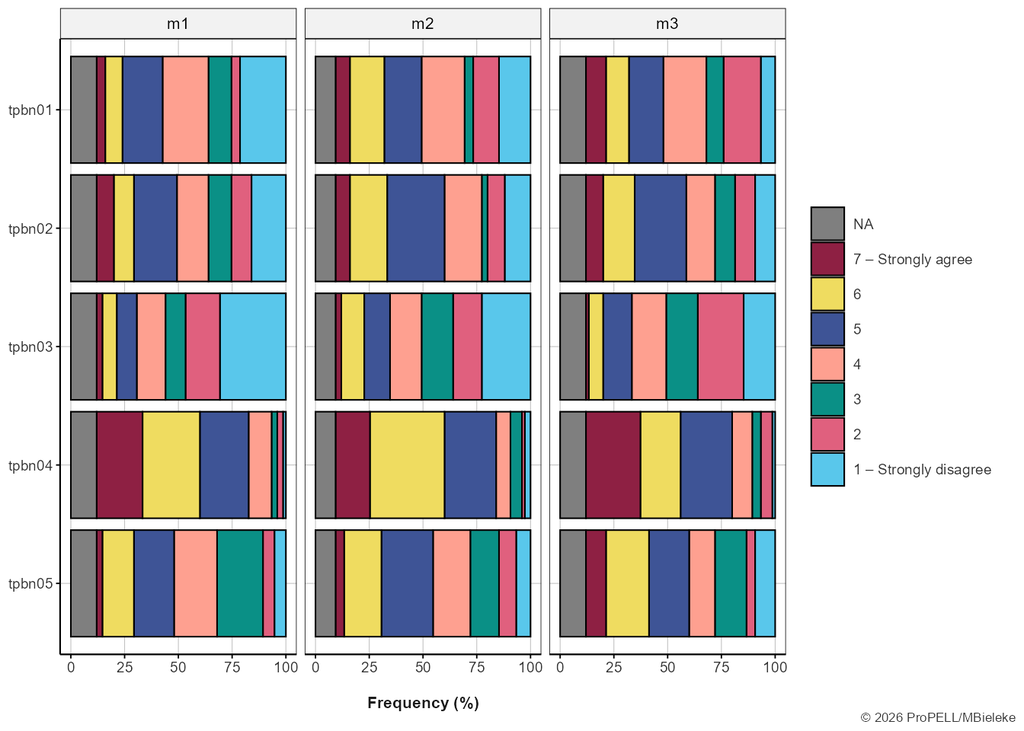

**Scale**

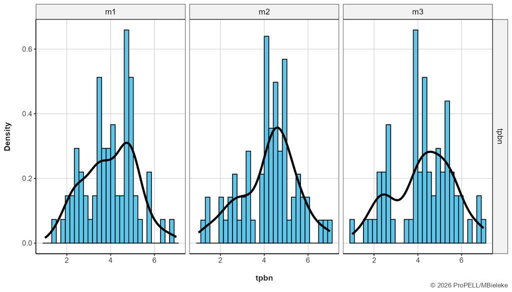

**Statistics**

**Items**

| Variable | N | #Valid | %Valid | Mean | SD | Min | Median | Max |
| --- | --- | --- | --- | --- | --- | --- | --- | --- |
| **tpbn01** |  |  |  |  |  |  |  |  |
| m1 | 75 | 66 | 88.00 | 3.59 | 1.83 | 1 | 4.0 | 7 |
| m2 | 75 | 68 | 90.67 | 3.97 | 1.91 | 1 | 4.0 | 7 |
| m3 | 75 | 66 | 88.00 | 4.03 | 1.80 | 1 | 4.0 | 7 |
| **tpbn02** |  |  |  |  |  |  |  |  |
| m1 | 75 | 66 | 88.00 | 3.83 | 1.92 | 1 | 4.0 | 7 |
| m2 | 75 | 68 | 90.67 | 4.29 | 1.80 | 1 | 5.0 | 7 |
| m3 | 75 | 66 | 88.00 | 4.24 | 1.80 | 1 | 5.0 | 7 |
| **tpbn03** |  |  |  |  |  |  |  |  |
| m1 | 75 | 66 | 88.00 | 2.83 | 1.83 | 1 | 2.0 | 7 |
| m2 | 75 | 68 | 90.67 | 3.25 | 1.83 | 1 | 3.0 | 7 |
| m3 | 75 | 66 | 88.00 | 3.20 | 1.62 | 1 | 3.0 | 7 |
| **tpbn04** |  |  |  |  |  |  |  |  |
| m1 | 75 | 66 | 88.00 | 5.45 | 1.36 | 1 | 6.0 | 7 |
| m2 | 75 | 68 | 90.67 | 5.38 | 1.37 | 1 | 6.0 | 7 |
| m3 | 75 | 66 | 88.00 | 5.35 | 1.53 | 1 | 5.5 | 7 |
| **tpbn05** |  |  |  |  |  |  |  |  |
| m1 | 75 | 66 | 88.00 | 4.09 | 1.49 | 1 | 4.0 | 7 |
| m2 | 75 | 68 | 90.67 | 4.24 | 1.60 | 1 | 4.5 | 7 |
| m3 | 75 | 66 | 88.00 | 4.41 | 1.81 | 1 | 5.0 | 7 |

**Scale**

| Variable | N | #Valid | %Valid | SD | Mean | Min | Median | Max | #Items | Alpha |
| --- | --- | --- | --- | --- | --- | --- | --- | --- | --- | --- |
| **tpbn** |  |  |  |  |  |  |  |  |  |  |
| m1 | 75 | 66 | 88.00 | 1.19 | 3.96 | 1.4 | 4.1 | 6.8 | 5 | 0.74 |
| m2 | 75 | 68 | 90.67 | 1.29 | 4.23 | 1.2 | 4.4 | 7.0 | 5 | 0.81 |
| m3 | 75 | 66 | 88.00 | 1.39 | 4.25 | 1.0 | 4.4 | 7.0 | 5 | 0.87 |

### No overall Trait SCC score is computed

**Overview**

- **Variable Stem: `traitscc`**
- **Time Points:** m1, m2, m3
- **Reference:** Custom scale

**Details**

**Items**

**Directions**: Please indicate how strongly you agree with each of the following statements.

| Variable | Scale | Prompt |
| --- | --- | --- |
| traitscc01 | Unpleasantness | Sport is ... unpleasant. |
| traitscc02 | Physical Demand | Sport is ... physically demanding. |
| traitscc03 | Cognitive demand | Sport is ... mentally demanding. |
| traitscc04 | Meaninglessness | Sport is ... meaningless. |
| traitscc05 | Frustration | Sport is ... frustrating. |
| traitscc06 | Difficulty | Sport is ... difficult. |
| traitscc07 | Tiresomness | Sport is ... tiring. |
| traitscc08 | Boringness | Sport is ... boring. |

Note. Variables with * have been reverse-coded

**Scale**

| Variable | Description |
| --- | --- |
| traitscc | No overall Trait SCC score is computed |

**Distribution**

**Items**

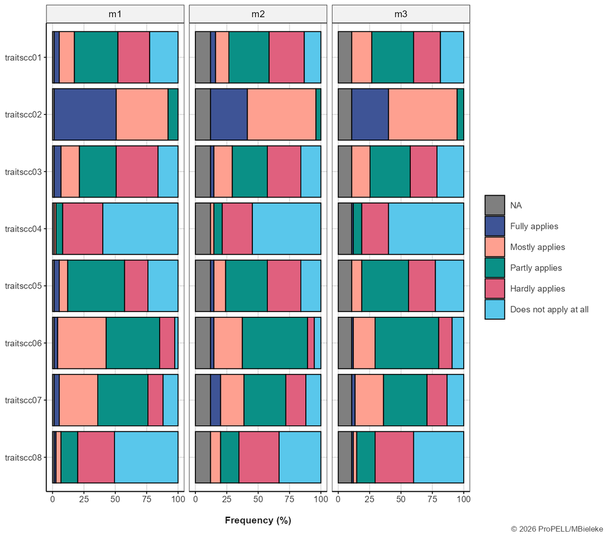

**Scale**

No overall score is available for this scale.

**Statistics**

**Items**

| Variable | N | #Valid | %Valid | Mean | SD | Min | Median | Max |
| --- | --- | --- | --- | --- | --- | --- | --- | --- |
| **traitscc01** |  |  |  |  |  |  |  |  |
| m1 | 75 | 74 | 98.67 | 2.49 | 1.10 | 1 | 3.0 | 5 |
| m2 | 75 | 66 | 88.00 | 2.59 | 1.04 | 1 | 3.0 | 5 |
| m3 | 75 | 67 | 89.33 | 2.52 | 1.02 | 1 | 3.0 | 4 |
| **traitscc02** |  |  |  |  |  |  |  |  |
| m1 | 75 | 74 | 98.67 | 4.42 | 0.64 | 3 | 4.5 | 5 |
| m2 | 75 | 66 | 88.00 | 4.29 | 0.55 | 3 | 4.0 | 5 |
| m3 | 75 | 67 | 89.33 | 4.27 | 0.57 | 3 | 4.0 | 5 |
| **traitscc03** |  |  |  |  |  |  |  |  |
| m1 | 75 | 74 | 98.67 | 2.59 | 1.10 | 1 | 2.5 | 5 |
| m2 | 75 | 66 | 88.00 | 2.56 | 1.07 | 1 | 3.0 | 5 |
| m3 | 75 | 67 | 89.33 | 2.45 | 1.03 | 1 | 3.0 | 4 |
| **traitscc04** |  |  |  |  |  |  |  |  |
| m1 | 75 | 74 | 98.67 | 1.47 | 0.67 | 1 | 1.0 | 4 |
| m2 | 75 | 66 | 88.00 | 1.52 | 0.77 | 1 | 1.0 | 4 |
| m3 | 75 | 67 | 89.33 | 1.45 | 0.76 | 1 | 1.0 | 5 |
| **traitscc05** |  |  |  |  |  |  |  |  |
| m1 | 75 | 74 | 98.67 | 2.47 | 1.06 | 1 | 3.0 | 5 |
| m2 | 75 | 66 | 88.00 | 2.50 | 1.01 | 1 | 3.0 | 5 |
| m3 | 75 | 67 | 89.33 | 2.34 | 0.96 | 1 | 3.0 | 4 |
| **traitscc06** |  |  |  |  |  |  |  |  |
| m1 | 75 | 74 | 98.67 | 3.27 | 0.82 | 1 | 3.0 | 5 |
| m2 | 75 | 66 | 88.00 | 3.14 | 0.82 | 1 | 3.0 | 5 |
| m3 | 75 | 67 | 89.33 | 2.90 | 0.89 | 1 | 3.0 | 5 |
| **traitscc07** |  |  |  |  |  |  |  |  |
| m1 | 75 | 74 | 98.67 | 3.03 | 1.05 | 1 | 3.0 | 5 |
| m2 | 75 | 66 | 88.00 | 2.94 | 1.15 | 1 | 3.0 | 5 |
| m3 | 75 | 67 | 89.33 | 2.84 | 1.07 | 1 | 3.0 | 5 |
| **traitscc08** |  |  |  |  |  |  |  |  |
| m1 | 75 | 74 | 98.67 | 1.74 | 0.94 | 1 | 1.0 | 5 |
| m2 | 75 | 66 | 88.00 | 1.97 | 0.96 | 1 | 2.0 | 4 |
| m3 | 75 | 67 | 89.33 | 1.82 | 0.92 | 1 | 2.0 | 5 |

**Scale**

No overall score is available for this scale.

### No overall Trait SCC Frequency score is computed

**Overview**

- **Variable Stem: `traitscsf`**
- **Time Points:** m1, m2, m3
- **Reference:** Custom scale

**Details**

**Items**

**Directions**: Please indicate how often you use the following strategies when exercising requires effort to overcome, and how often these strategies are helpful. How often do you use the strategies?

| Variable | Scale | Prompt |
| --- | --- | --- |
| traitscsf01 | Situation Modification | Create a pleasant situation for doing sports (e.g., choosing a nice environment, doing sports with others, varying the activity) |
| traitscsf02 | Attention Deployment | Focus on specific aspects of the sport (e.g., execution of the movement) and ignore others (e.g., tempting alternatives) |
| traitscsf03 | Cognitive Change | Mentally prepare for doing sports (e.g., focusing on positive effects, goals, and rewards, self-encouragement) |
| traitscsf04 | Response Modulation | Force myself to do sports (e.g., suppressing the urge to do something else) |
| traitscsf05 | Emotion Regulation | Control my emotions (e.g., trying to stay in a good mood) |

Note. Variables with * have been reverse-coded

**Scale**

| Variable | Description |
| --- | --- |
| traitscsf | No overall Trait SCC Frequency score is computed |

**Distribution**

**Items**

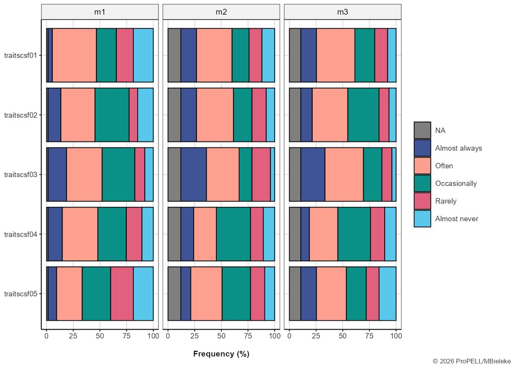

**Scale**

No overall score is available for this scale.

**Statistics**

**Items**

| Variable | N | #Valid | %Valid | Mean | SD | Min | Median | Max |
| --- | --- | --- | --- | --- | --- | --- | --- | --- |
| **traitscsf01** |  |  |  |  |  |  |  |  |
| m1 | 75 | 74 | 98.67 | 2.96 | 1.23 | 1 | 3 | 5 |
| m2 | 75 | 66 | 88.00 | 3.30 | 1.29 | 1 | 4 | 5 |
| m3 | 75 | 67 | 89.33 | 3.42 | 1.18 | 1 | 4 | 5 |
| **traitscsf02** |  |  |  |  |  |  |  |  |
| m1 | 75 | 74 | 98.67 | 3.19 | 1.21 | 1 | 3 | 5 |
| m2 | 75 | 66 | 88.00 | 3.39 | 1.20 | 1 | 4 | 5 |
| m3 | 75 | 67 | 89.33 | 3.36 | 1.07 | 1 | 3 | 5 |
| **traitscsf03** |  |  |  |  |  |  |  |  |
| m1 | 75 | 74 | 98.67 | 3.43 | 1.14 | 1 | 4 | 5 |
| m2 | 75 | 66 | 88.00 | 3.61 | 1.21 | 1 | 4 | 5 |
| m3 | 75 | 67 | 89.33 | 3.72 | 1.10 | 1 | 4 | 5 |
| **traitscsf04** |  |  |  |  |  |  |  |  |
| m1 | 75 | 74 | 98.67 | 3.24 | 1.19 | 1 | 3 | 5 |
| m2 | 75 | 66 | 88.00 | 3.14 | 1.19 | 1 | 3 | 5 |
| m3 | 75 | 67 | 89.33 | 3.09 | 1.14 | 1 | 3 | 5 |
| **traitscsf05** |  |  |  |  |  |  |  |  |
| m1 | 75 | 74 | 98.67 | 2.81 | 1.24 | 1 | 3 | 5 |
| m2 | 75 | 66 | 88.00 | 3.18 | 1.15 | 1 | 3 | 5 |
| m3 | 75 | 67 | 89.33 | 3.15 | 1.35 | 1 | 3 | 5 |

**Scale**

No overall score is available for this scale.

### No overall Trait SCC Success score is computed

**Overview**

- **Variable Stem: `traitscss`**
- **Time Points:** m1, m2, m3
- **Reference:** Custom scale

**Details**

**Items**

**Directions**: Please indicate how often you use the following strategies when exercising requires effort to overcome, and how often these strategies are helpful. How often are the strategies helpful?

| Variable | Scale | Prompt |
| --- | --- | --- |
| traitscss01 | Situation Modification | Create a pleasant situation for doing sports (e.g., choosing a nice environment, doing sports with others, varying the activity) |
| traitscss02 | Attention Deployment | Focus on specific aspects of the sport (e.g., execution of the movement) and ignore others (e.g., tempting alternatives) |
| traitscss03 | Cognitive Change | Mentally prepare for doing sports (e.g., focusing on positive effects, goals, and rewards, self-encouragement) |
| traitscss04 | Response Modulation | Force myself to do sports (e.g., suppressing the urge to do something else) |
| traitscss05 | Emotion Regulation | Control my emotions (e.g., trying to stay in a good mood) |

Note. Variables with * have been reverse-coded

**Scale**

| Variable | Description |
| --- | --- |
| traitscss | No overall Trait SCC Success score is computed |

**Distribution**

**Items**

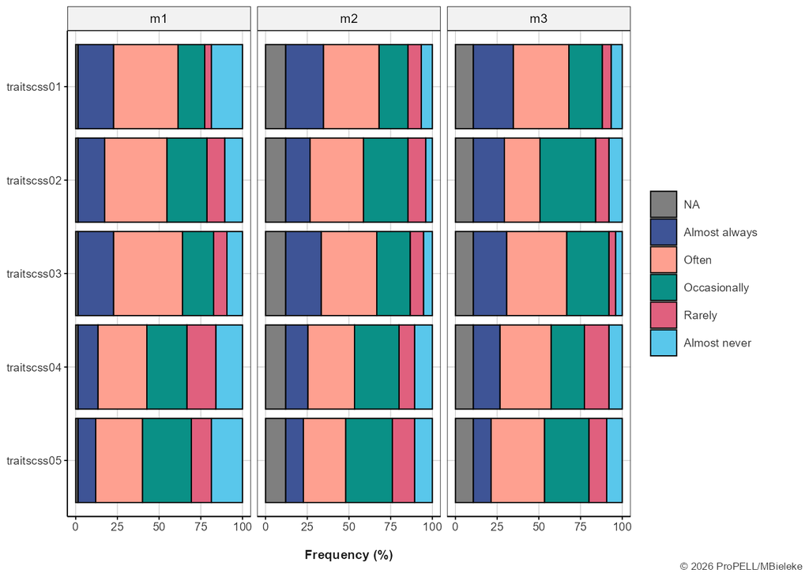

**Scale**

No overall score is available for this scale.

**Statistics**

**Items**

| Variable | N | #Valid | %Valid | Mean | SD | Min | Median | Max |
| --- | --- | --- | --- | --- | --- | --- | --- | --- |
| **traitscss01** |  |  |  |  |  |  |  |  |
| m1 | 75 | 74 | 98.67 | 3.41 | 1.38 | 1 | 4 | 5 |
| m2 | 75 | 66 | 88.00 | 3.65 | 1.18 | 1 | 4 | 5 |
| m3 | 75 | 67 | 89.33 | 3.70 | 1.15 | 1 | 4 | 5 |
| **traitscss02** |  |  |  |  |  |  |  |  |
| m1 | 75 | 74 | 98.67 | 3.38 | 1.20 | 1 | 4 | 5 |
| m2 | 75 | 66 | 88.00 | 3.48 | 1.06 | 1 | 4 | 5 |
| m3 | 75 | 67 | 89.33 | 3.39 | 1.18 | 1 | 3 | 5 |
| **traitscss03** |  |  |  |  |  |  |  |  |
| m1 | 75 | 74 | 98.67 | 3.58 | 1.19 | 1 | 4 | 5 |
| m2 | 75 | 66 | 88.00 | 3.65 | 1.13 | 1 | 4 | 5 |
| m3 | 75 | 67 | 89.33 | 3.72 | 1.01 | 1 | 4 | 5 |
| **traitscss04** |  |  |  |  |  |  |  |  |
| m1 | 75 | 74 | 98.67 | 3.04 | 1.28 | 1 | 3 | 5 |
| m2 | 75 | 66 | 88.00 | 3.27 | 1.21 | 1 | 3 | 5 |
| m3 | 75 | 67 | 89.33 | 3.36 | 1.21 | 1 | 4 | 5 |
| **traitscss05** |  |  |  |  |  |  |  |  |
| m1 | 75 | 74 | 98.67 | 3.00 | 1.27 | 1 | 3 | 5 |
| m2 | 75 | 66 | 88.00 | 3.14 | 1.19 | 1 | 3 | 5 |
| m3 | 75 | 67 | 89.33 | 3.27 | 1.15 | 1 | 3 | 5 |

**Scale**

No overall score is available for this scale.

### Overall UMS mean score

**Overview**

- **Variable Stem: `ums`**
- **Time Points:** m1, m2, m3
- **Reference:** Schönbrodt & Gerstenberg (2012)

**Details**

**Items**

| Variable | Scale | Prompt |
| --- | --- | --- |
| ums01 | Achievement | Maintaining high standards for the quality of my work |
| ums02 | Achievement | Personally producing work of high quality |
| ums03 | Achievement | Projects that challenge me to the limits of my ability |

Note. Variables with * have been reverse-coded

**Scale**

| Variable | Description |
| --- | --- |
| ums | Overall UMS mean score |

**Distribution**

**Items**

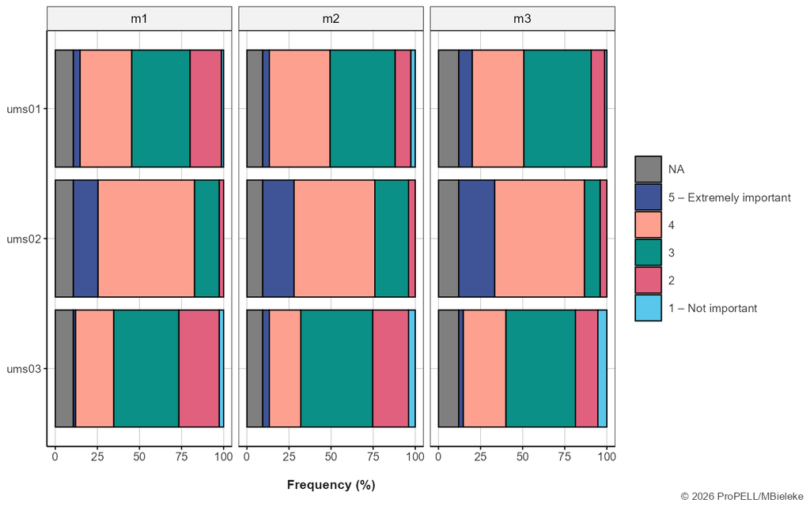

**Scale**

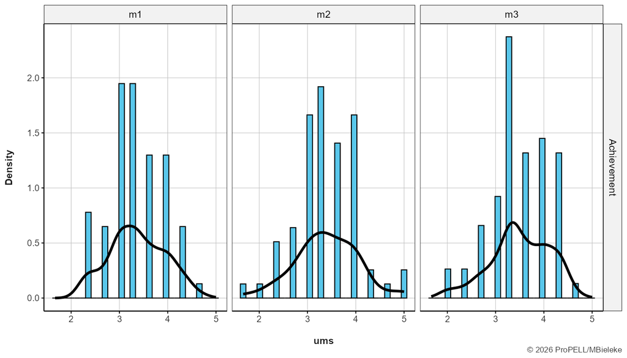

**Statistics**

**Items**

| Variable | N | #Valid | %Valid | Mean | SD | Min | Median | Max |
| --- | --- | --- | --- | --- | --- | --- | --- | --- |
| **ums01** |  |  |  |  |  |  |  |  |
| m1 | 75 | 67 | 89.33 | 3.19 | 0.87 | 1 | 3 | 5 |
| m2 | 75 | 68 | 90.67 | 3.32 | 0.84 | 1 | 3 | 5 |
| m3 | 75 | 66 | 88.00 | 3.41 | 0.84 | 1 | 3 | 5 |
| **ums02** |  |  |  |  |  |  |  |  |
| m1 | 75 | 67 | 89.33 | 3.94 | 0.67 | 2 | 4 | 5 |
| m2 | 75 | 68 | 90.67 | 3.90 | 0.78 | 2 | 4 | 5 |
| m3 | 75 | 66 | 88.00 | 4.05 | 0.73 | 2 | 4 | 5 |
| **ums03** |  |  |  |  |  |  |  |  |
| m1 | 75 | 67 | 89.33 | 2.96 | 0.84 | 1 | 3 | 5 |
| m2 | 75 | 68 | 90.67 | 2.97 | 0.90 | 1 | 3 | 5 |
| m3 | 75 | 66 | 88.00 | 3.08 | 0.90 | 1 | 3 | 5 |

**Scale**

| Variable | N | #Valid | %Valid | SD | Mean | Min | Median | Max | #Items | Alpha |
| --- | --- | --- | --- | --- | --- | --- | --- | --- | --- | --- |
| **ums** |  |  |  |  |  |  |  |  |  |  |
| m1 | 75 | 67 | 89.33 | 0.58 | 3.36 | 2.33 | 3.33 | 4.67 | 3 | 0.54 |
| m2 | 75 | 68 | 90.67 | 0.65 | 3.40 | 1.67 | 3.33 | 5.00 | 3 | 0.67 |
| m3 | 75 | 66 | 88.00 | 0.61 | 3.51 | 2.00 | 3.33 | 4.67 | 3 | 0.58 |

### Overall Perceived Value mean score

**Overview**

- **Variable Stem: `value`**
- **Time Points:** m1, m2, m3
- **Reference:** Gaspard et al. (2017)

**Details**

**Items**

**Directions**: The following statements concern your beliefs and attitudes toward exercise. Please read each statement and indicate how strongly you agree with it.

| Variable | Scale | Prompt |
| --- | --- | --- |
| value01 | Intrinsic | I enjoy doing sports. |
| value02 | Intrinsic | I simply like sports. |
| value03 | Intrinsic | I like doing sports. |
| value04 | Intrinsic | Sport is fun to me. |
| value05 | Attainment | It is very important to me to be good at sports. |
| value06 | Attainment | Compared to my other activities, it is very important to me to perform well in sports. |
| value07 | Attainment | I am only satisfied when I perform well in sports. |
| value08 | Attainment | Performing well in sports means a lot to me. |
| value09 | Utility | Being good at sports is useful to me. |
| value10 | Utility | It is worthwhile for me to do sports. |
| value11 | Utility | Sports are a good way to do something useful. |
| value12 | Utility | Doing sports helps me in my life. |

Note. Variables with * have been reverse-coded

**Scale**

| Variable | Description |
| --- | --- |
| value | Overall Perceived Value mean score |

**Distribution**

**Items**

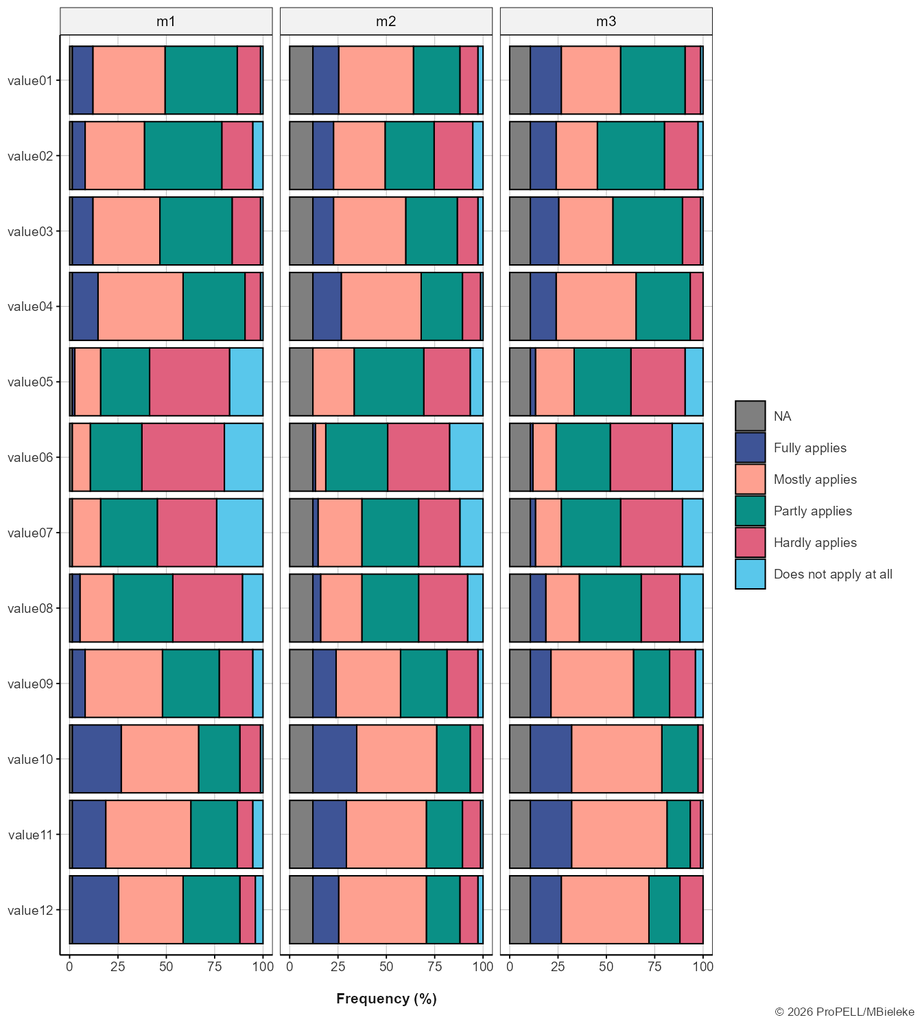

**Scale**

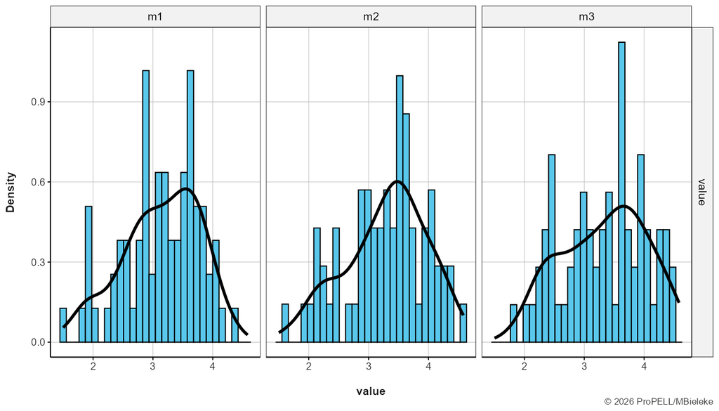

**Statistics**

**Items**

| Variable | N | #Valid | %Valid | Mean | SD | Min | Median | Max |
| --- | --- | --- | --- | --- | --- | --- | --- | --- |
| **value01** |  |  |  |  |  |  |  |  |
| m1 | 75 | 74 | 98.67 | 3.45 | 0.89 | 1 | 3 | 5 |
| m2 | 75 | 66 | 88.00 | 3.58 | 0.98 | 1 | 4 | 5 |
| m3 | 75 | 67 | 89.33 | 3.58 | 0.94 | 1 | 4 | 5 |
| **value02** |  |  |  |  |  |  |  |  |
| m1 | 75 | 74 | 98.67 | 3.18 | 0.97 | 1 | 3 | 5 |
| m2 | 75 | 66 | 88.00 | 3.20 | 1.11 | 1 | 3 | 5 |
| m3 | 75 | 67 | 89.33 | 3.28 | 1.04 | 1 | 3 | 5 |
| **value03** |  |  |  |  |  |  |  |  |
| m1 | 75 | 74 | 98.67 | 3.39 | 0.92 | 1 | 3 | 5 |
| m2 | 75 | 66 | 88.00 | 3.48 | 0.96 | 1 | 4 | 5 |
| m3 | 75 | 67 | 89.33 | 3.51 | 0.94 | 1 | 3 | 5 |
| **value04** |  |  |  |  |  |  |  |  |
| m1 | 75 | 74 | 98.67 | 3.61 | 0.87 | 1 | 4 | 5 |
| m2 | 75 | 66 | 88.00 | 3.67 | 0.93 | 1 | 4 | 5 |
| m3 | 75 | 67 | 89.33 | 3.69 | 0.82 | 2 | 4 | 5 |
| **value05** |  |  |  |  |  |  |  |  |
| m1 | 75 | 74 | 98.67 | 2.39 | 0.98 | 1 | 2 | 5 |
| m2 | 75 | 66 | 88.00 | 2.82 | 0.89 | 1 | 3 | 4 |
| m3 | 75 | 67 | 89.33 | 2.76 | 1.02 | 1 | 3 | 5 |
| **value06** |  |  |  |  |  |  |  |  |
| m1 | 75 | 74 | 98.67 | 2.26 | 0.89 | 1 | 2 | 4 |
| m2 | 75 | 66 | 88.00 | 2.33 | 0.92 | 1 | 2 | 5 |
| m3 | 75 | 67 | 89.33 | 2.45 | 0.99 | 1 | 2 | 5 |
| **value07** |  |  |  |  |  |  |  |  |
| m1 | 75 | 74 | 98.67 | 2.35 | 1.01 | 1 | 2 | 4 |
| m2 | 75 | 66 | 88.00 | 2.80 | 1.07 | 1 | 3 | 5 |
| m3 | 75 | 67 | 89.33 | 2.61 | 0.98 | 1 | 3 | 5 |
| **value08** |  |  |  |  |  |  |  |  |
| m1 | 75 | 74 | 98.67 | 2.68 | 1.02 | 1 | 3 | 5 |
| m2 | 75 | 66 | 88.00 | 2.86 | 1.04 | 1 | 3 | 5 |
| m3 | 75 | 67 | 89.33 | 2.88 | 1.15 | 1 | 3 | 5 |
| **value09** |  |  |  |  |  |  |  |  |
| m1 | 75 | 74 | 98.67 | 3.26 | 1.01 | 1 | 3 | 5 |
| m2 | 75 | 66 | 88.00 | 3.41 | 1.04 | 1 | 4 | 5 |
| m3 | 75 | 67 | 89.33 | 3.48 | 1.04 | 1 | 4 | 5 |
| **value10** |  |  |  |  |  |  |  |  |
| m1 | 75 | 74 | 98.67 | 3.78 | 1.00 | 1 | 4 | 5 |
| m2 | 75 | 66 | 88.00 | 3.91 | 0.87 | 2 | 4 | 5 |
| m3 | 75 | 67 | 89.33 | 3.97 | 0.76 | 2 | 4 | 5 |
| **value11** |  |  |  |  |  |  |  |  |
| m1 | 75 | 74 | 98.67 | 3.61 | 1.04 | 1 | 4 | 5 |
| m2 | 75 | 66 | 88.00 | 3.73 | 0.95 | 1 | 4 | 5 |
| m3 | 75 | 67 | 89.33 | 3.94 | 0.87 | 1 | 4 | 5 |
| **value12** |  |  |  |  |  |  |  |  |
| m1 | 75 | 74 | 98.67 | 3.66 | 1.06 | 1 | 4 | 5 |
| m2 | 75 | 66 | 88.00 | 3.65 | 0.97 | 1 | 4 | 5 |
| m3 | 75 | 67 | 89.33 | 3.73 | 0.91 | 2 | 4 | 5 |

**Scale**

| Variable | N | #Valid | %Valid | SD | Mean | Min | Median | Max | #Items | Alpha |
| --- | --- | --- | --- | --- | --- | --- | --- | --- | --- | --- |
| **value** |  |  |  |  |  |  |  |  |  |  |
| m1 | 75 | 74 | 98.67 | 0.64 | 3.13 | 1.50 | 3.21 | 4.33 | 12 | 0.88 |
| m2 | 75 | 66 | 88.00 | 0.68 | 3.29 | 1.58 | 3.42 | 4.58 | 12 | 0.90 |
| m3 | 75 | 67 | 89.33 | 0.70 | 3.32 | 1.83 | 3.42 | 4.50 | 12 | 0.92 |

### Overall VoPE mean score

**Overview**

- **Variable Stem: `vope`**
- **Time Points:** m1, m2, m3
- **Reference:** Bieleke et al. (2023)

**Details**

**Items**

**Directions**: The following statements refer to sports activities that are physically demanding. The term physical exertion refers to your perception of how hard, strenuous, and challenging sports activities are. Please read each statement and indicate the extent to which it generally applies to you.

| Variable | Prompt |
| --- | --- |
| vope01 | I greatly enjoy sports activities that require physical effort. |
| vope02 | I prefer physically effortful sports activities to those that can be done without much effort. |
| vope03* | I find it hard to get enthusiastic about new sports activities if they involve physical effort. |
| vope04 | The notion of physically exerting myself in sports appeals to me. |
| vope05* | I physically exert myself in sports only as much as I absolutely have to. |
| vope06* | I try to anticipate and avoid situations in sports where there is a good chance that I will have to physically exert myself. |
| vope07* | Other things equal, I would rather do sports activities with less physical effort. |
| vope08* | A sports activity feels like a burden as soon as I start thinking about the physical effort involved. |
| vope09 | I enjoy physically exerting myself in a sports activity even when it will have no effect on the result. |
| vope10 | When I know that a sports activity is going to involve physical effort, I look forward to it, even if I do not know what exactly it involves. |

Note. Variables with * have been reverse-coded

**Scale**

| Variable | Description |
| --- | --- |
| vope | Overall VoPE mean score |

**Distribution**

**Items**

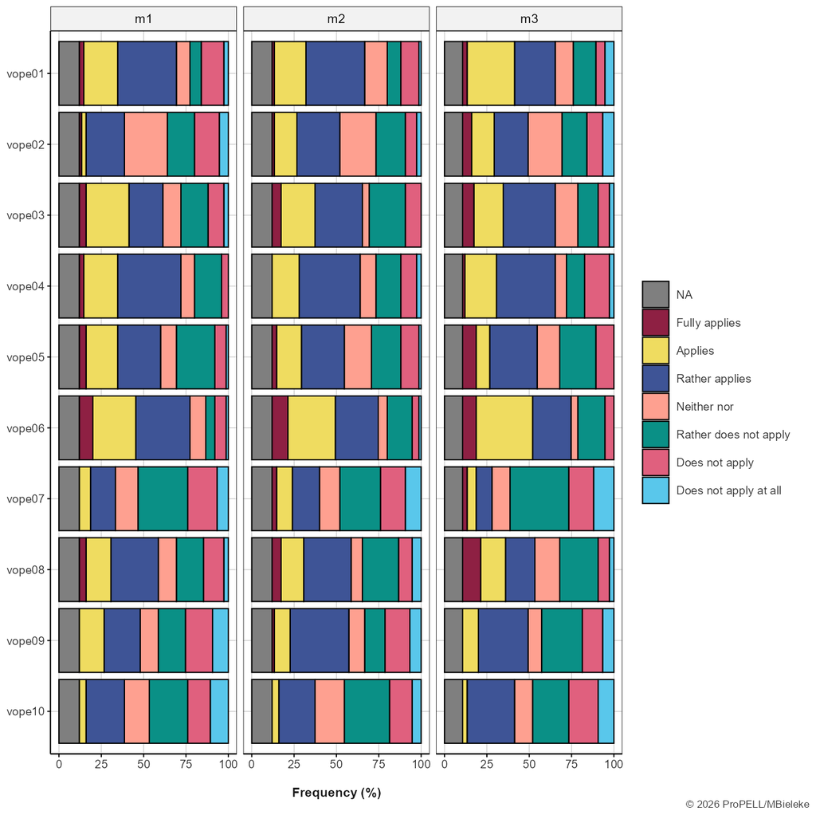

**Scale**

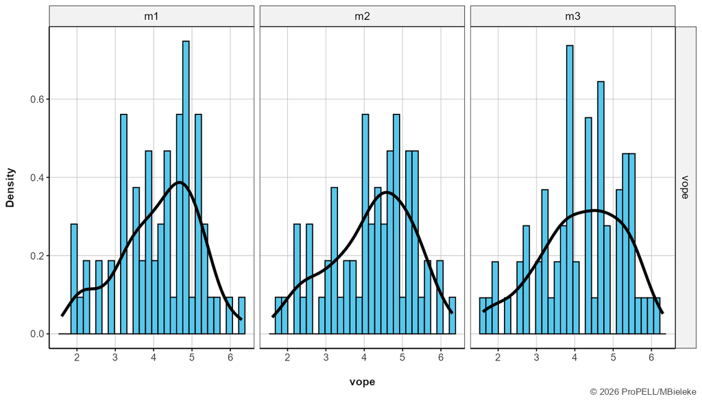

**Statistics**

**Items**

| Variable | N | #Valid | %Valid | Mean | SD | Min | Median | Max |
| --- | --- | --- | --- | --- | --- | --- | --- | --- |
| **vope01** |  |  |  |  |  |  |  |  |
| m1 | 75 | 66 | 88.00 | 4.47 | 1.53 | 1 | 5 | 7 |
| m2 | 75 | 66 | 88.00 | 4.48 | 1.37 | 1 | 5 | 7 |
| m3 | 75 | 67 | 89.33 | 4.54 | 1.57 | 1 | 5 | 7 |
| **vope02** |  |  |  |  |  |  |  |  |
| m1 | 75 | 66 | 88.00 | 3.67 | 1.35 | 1 | 4 | 7 |
| m2 | 75 | 66 | 88.00 | 4.20 | 1.34 | 1 | 4 | 7 |
| m3 | 75 | 67 | 89.33 | 4.10 | 1.62 | 1 | 4 | 7 |
| **vope03** |  |  |  |  |  |  |  |  |
| m1 | 75 | 66 | 88.00 | 4.45 | 1.58 | 1 | 5 | 7 |
| m2 | 75 | 66 | 88.00 | 4.50 | 1.49 | 2 | 5 | 7 |
| m3 | 75 | 67 | 89.33 | 4.58 | 1.48 | 1 | 5 | 7 |
| **vope04** |  |  |  |  |  |  |  |  |
| m1 | 75 | 66 | 88.00 | 4.70 | 1.23 | 2 | 5 | 7 |
| m2 | 75 | 66 | 88.00 | 4.30 | 1.39 | 1 | 5 | 6 |
| m3 | 75 | 67 | 89.33 | 4.31 | 1.53 | 1 | 5 | 7 |
| **vope05** |  |  |  |  |  |  |  |  |
| m1 | 75 | 66 | 88.00 | 4.39 | 1.46 | 1 | 5 | 7 |
| m2 | 75 | 66 | 88.00 | 4.23 | 1.42 | 1 | 4 | 7 |
| m3 | 75 | 67 | 89.33 | 4.28 | 1.46 | 2 | 4 | 7 |
| **vope06** |  |  |  |  |  |  |  |  |
| m1 | 75 | 66 | 88.00 | 4.95 | 1.40 | 1 | 5 | 7 |
| m2 | 75 | 66 | 88.00 | 4.94 | 1.47 | 1 | 5 | 7 |
| m3 | 75 | 67 | 89.33 | 4.97 | 1.44 | 2 | 5 | 7 |
| **vope07** |  |  |  |  |  |  |  |  |
| m1 | 75 | 66 | 88.00 | 3.36 | 1.38 | 1 | 3 | 6 |
| m2 | 75 | 66 | 88.00 | 3.56 | 1.62 | 1 | 3 | 7 |
| m3 | 75 | 67 | 89.33 | 3.19 | 1.50 | 1 | 3 | 7 |
| **vope08** |  |  |  |  |  |  |  |  |
| m1 | 75 | 66 | 88.00 | 4.24 | 1.54 | 1 | 5 | 7 |
| m2 | 75 | 66 | 88.00 | 4.20 | 1.62 | 1 | 5 | 7 |
| m3 | 75 | 67 | 89.33 | 4.39 | 1.62 | 1 | 4 | 7 |
| **vope09** |  |  |  |  |  |  |  |  |
| m1 | 75 | 66 | 88.00 | 3.71 | 1.65 | 1 | 4 | 6 |
| m2 | 75 | 66 | 88.00 | 3.95 | 1.57 | 1 | 5 | 7 |
| m3 | 75 | 67 | 89.33 | 3.78 | 1.49 | 1 | 4 | 6 |
| **vope10** |  |  |  |  |  |  |  |  |
| m1 | 75 | 66 | 88.00 | 3.42 | 1.45 | 1 | 3 | 6 |
| m2 | 75 | 66 | 88.00 | 3.55 | 1.30 | 1 | 3 | 6 |
| m3 | 75 | 67 | 89.33 | 3.43 | 1.45 | 1 | 3 | 6 |

**Scale**

| Variable | N | #Valid | %Valid | SD | Mean | Min | Median | Max | #Items | Alpha |
| --- | --- | --- | --- | --- | --- | --- | --- | --- | --- | --- |
| **vope** |  |  |  |  |  |  |  |  |  |  |
| m1 | 75 | 66 | 88.00 | 1.03 | 4.14 | 1.9 | 4.3 | 6.3 | 10 | 0.89 |
| m2 | 75 | 66 | 88.00 | 1.08 | 4.19 | 1.7 | 4.4 | 6.3 | 10 | 0.91 |
| m3 | 75 | 67 | 89.33 | 1.10 | 4.16 | 1.6 | 4.4 | 6.1 | 10 | 0.90 |

### Overall WHOWBS mean score

**Overview**

- **Variable Stem: `whowbs`**
- **Time Points:** m1, m2, m3
- **Reference:** Brähler et al. (2007)

**Note:** This scale has been added in the second wave of data collection. Accordingly, data from the first wave is not available.

**Details**

**Items**

**Directions**: Please indicate for each of the following statements the extent to which it applied to you over the past four weeks.

| Variable | Prompt |
| --- | --- |
| whowbs01 | In the last four weeks ... I have felt cheerful in good spirits. |
| whowbs02 | In the last four weeks ... I have felt calm and relaxed. |
| whowbs03 | In the last four weeks ... I have felt active and vigorous. |
| whowbs04 | In the last four weeks ... I woke up feeling fresh and rested. |
| whowbs05 | In the last four weeks ... my daily life has been filled with things that interest me. |

Note. Variables with * have been reverse-coded

**Scale**

| Variable | Description |
| --- | --- |
| whowbs | Overall WHOWBS mean score |

**Distribution**

**Items**

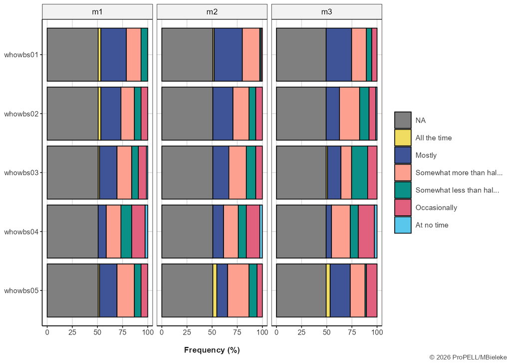

**Scale**

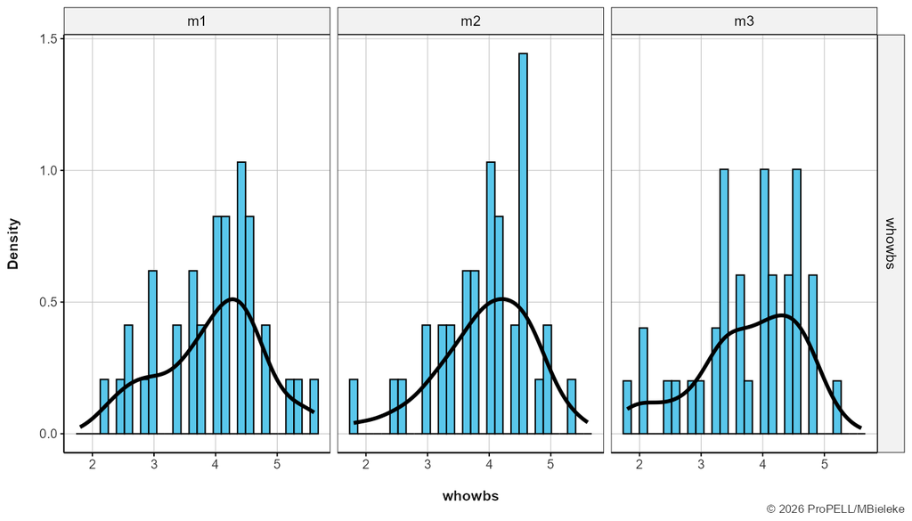

**Statistics**

**Items**

| Variable | N | #Valid | %Valid | Mean | SD | Min | Median | Max |
| --- | --- | --- | --- | --- | --- | --- | --- | --- |
| **whowbs01** |  |  |  |  |  |  |  |  |
| m1 | 75 | 37 | 49.33 | 4.49 | 0.80 | 3 | 5.0 | 6 |
| m2 | 75 | 37 | 49.33 | 4.54 | 0.73 | 2 | 5.0 | 6 |
| m3 | 75 | 38 | 50.67 | 4.18 | 1.01 | 2 | 4.5 | 5 |
| **whowbs02** |  |  |  |  |  |  |  |  |
| m1 | 75 | 37 | 49.33 | 4.11 | 1.15 | 2 | 4.0 | 6 |
| m2 | 75 | 37 | 49.33 | 4.00 | 1.05 | 2 | 4.0 | 5 |
| m3 | 75 | 38 | 50.67 | 3.74 | 1.08 | 1 | 4.0 | 5 |
| **whowbs03** |  |  |  |  |  |  |  |  |
| m1 | 75 | 37 | 49.33 | 3.86 | 1.23 | 1 | 4.0 | 6 |
| m2 | 75 | 37 | 49.33 | 3.86 | 1.03 | 2 | 4.0 | 5 |
| m3 | 75 | 38 | 50.67 | 3.63 | 1.15 | 2 | 3.5 | 6 |
| **whowbs04** |  |  |  |  |  |  |  |  |
| m1 | 75 | 37 | 49.33 | 3.24 | 1.19 | 1 | 3.0 | 5 |
| m2 | 75 | 37 | 49.33 | 3.35 | 1.25 | 1 | 4.0 | 5 |
| m3 | 75 | 38 | 50.67 | 3.16 | 1.15 | 1 | 3.0 | 5 |
| **whowbs05** |  |  |  |  |  |  |  |  |
| m1 | 75 | 37 | 49.33 | 4.00 | 1.08 | 2 | 4.0 | 6 |
| m2 | 75 | 37 | 49.33 | 4.00 | 1.08 | 2 | 4.0 | 6 |
| m3 | 75 | 38 | 50.67 | 4.11 | 1.27 | 2 | 4.0 | 6 |

**Scale**

| Variable | N | #Valid | %Valid | SD | Mean | Min | Median | Max | #Items | Alpha |
| --- | --- | --- | --- | --- | --- | --- | --- | --- | --- | --- |
| **whowbs** |  |  |  |  |  |  |  |  |  |  |
| m1 | 75 | 37 | 49.33 | 0.83 | 3.94 | 2.2 | 4 | 5.6 | 5 | 0.81 |
| m2 | 75 | 37 | 49.33 | 0.77 | 3.95 | 1.8 | 4 | 5.4 | 5 | 0.79 |
| m3 | 75 | 38 | 50.67 | 0.85 | 3.76 | 1.8 | 4 | 5.2 | 5 | 0.81 |

### Overall WST mean score

**Overview**

- **Variable Stem: `wst`**
- **Time Points:** m1
- **Reference:** Schmidt & Metzler (1992)

**Details**

Below you will find rows of six letter strings. In each row, only one of them is a real word that you may know. Please identify this word and click on it. Here is an example: Renek – Skerk – Erenk – Kern – Nerk – Lersk. In this row, Kern is the correct word, so you should click on it. Please note: If you recognize a word as correct, simply click on it. You are not required to provide a definition of the word. However, please do not guess. If you do not know any of the words in a row, click “no answer.” Please read each row and do not skip any. Work at your own reasonable pace; you have enough time available.

**Distribution**

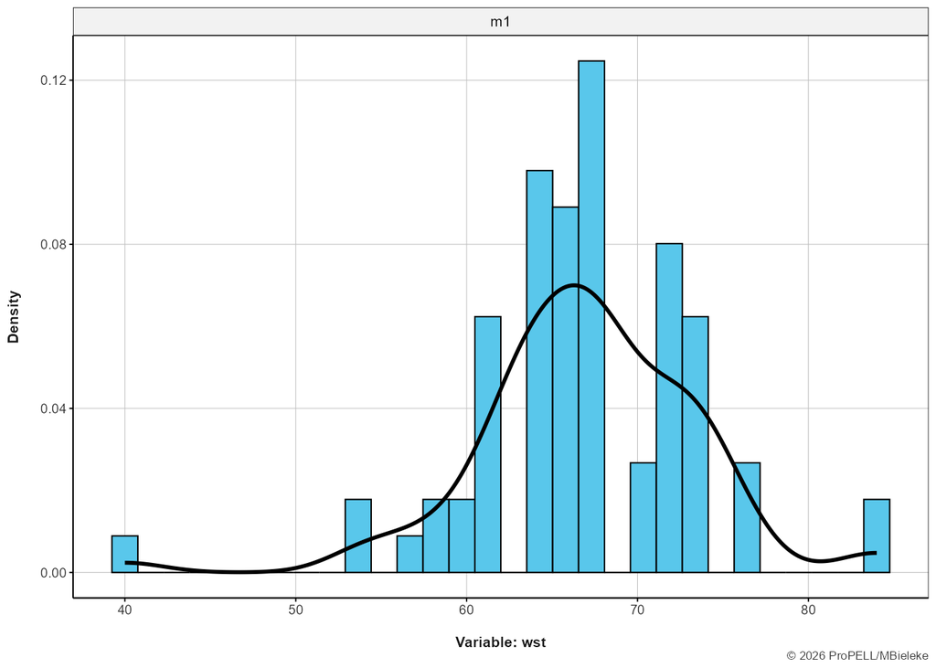

**Statistics**

| Time | N | % | %Val | Mean | SD | Min | Median | Max |
| --- | --- | --- | --- | --- | --- | --- | --- | --- |
| m1 | 75 | 74 | 98.67 | 67.05 | 6.58 | 40 | 68 | 84 |

# Demographics

### Type of current place of residence

**Overview**

- **Variable Stem: `currresid`**
- **Time Points:** m1
- **Reference:** Custom item

**Details**

Please provide the following information about your current place of residence.

**Distribution**

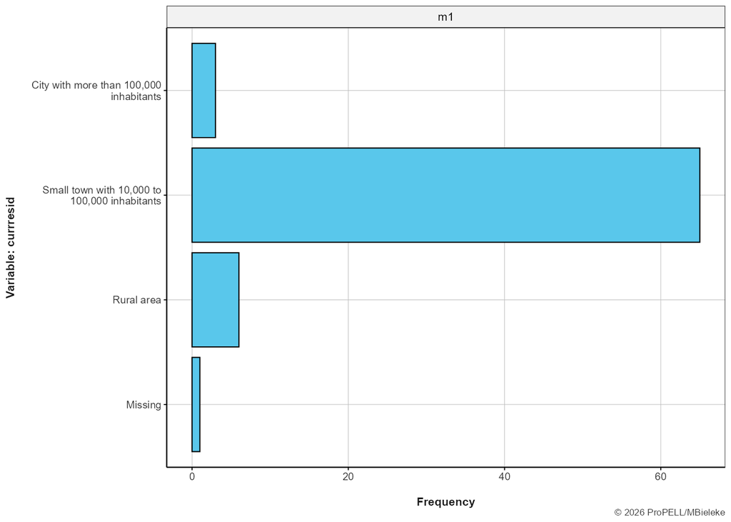

**Statistics**

| Answer | N | % | %Val |
| --- | --- | --- | --- |
| City with more than 100,000 inhabitants |  |  |  |
| m1 | 3 | 4.0 | 4.0 |
| Small town with 10,000 to 100,000 inhabitants |  |  |  |
| m1 | 65 | 86.7 | 87.8 |
| **Rural area** |  |  |  |
| m1 | 6 | 8.0 | 8.1 |
| **Missing** |  |  |  |
| m1 | 1 | 1.3 | --- |

### Highest educational qualification attained

**Overview**

- **Variable Stem: `education`**
- **Time Points:** m1
- **Reference:** Custom item

**Details**

What is your highest educational qualification?

**Distribution**

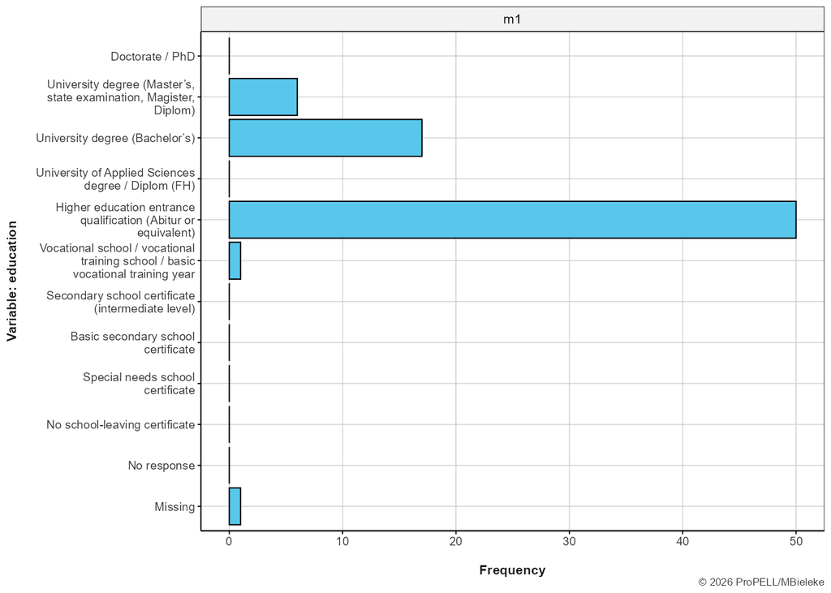

**Statistics**

| Answer | N | % | %Val |
| --- | --- | --- | --- |
| **Doctorate / PhD** |  |  |  |
| m1 | 0 | 0.0 | 0.0 |
| University degree (Master’s, state examination, Magister, Diplom) |  |  |  |
| m1 | 6 | 8.0 | 8.1 |
| **University degree (Bachelor’s)** |  |  |  |
| m1 | 17 | 22.7 | 23.0 |
| University of Applied Sciences degree / Diplom (FH) |  |  |  |
| m1 | 0 | 0.0 | 0.0 |
| Higher education entrance qualification (Abitur or equivalent) |  |  |  |
| m1 | 50 | 66.7 | 67.6 |
| Vocational school / vocational training school / basic vocational training year |  |  |  |
| m1 | 1 | 1.3 | 1.4 |
| Secondary school certificate (intermediate level) |  |  |  |
| m1 | 0 | 0.0 | 0.0 |
| Basic secondary school certificate |  |  |  |
| m1 | 0 | 0.0 | 0.0 |
| Special needs school certificate |  |  |  |
| m1 | 0 | 0.0 | 0.0 |
| **No school-leaving certificate** |  |  |  |
| m1 | 0 | 0.0 | 0.0 |
| **No response** |  |  |  |
| m1 | 0 | 0.0 | 0.0 |
| **Missing** |  |  |  |
| m1 | 1 | 1.3 | --- |

### No overall Employment score is computed

**Overview**

- **Variable Stem: `employment`**
- **Time Points:** m1
- **Reference:** Custom item

**Details**

What is your current employment and occupational status? You may select one or more response options.

| Variable | Label | Prompt |
| --- | --- | --- |
| employment01 | --- | Employed full-time |
| employment02 | --- | Employed part-time |
| employment03 | --- | Phased retirement |
| employment04 | --- | Marginally employed, €450 job, mini-job |
| employment05 | --- | “One-euro job” (while receiving unemployment benefit II) |
| employment06 | --- | Employed occasionally or irregularly |
| employment07 | --- | Self-employed or freelance work |
| employment08 | --- | Student |
| employment09 | --- | In vocational training/apprenticeship |
| employment10 | --- | Pupil at a general education school |
| employment11 | --- | In retraining |
| employment12 | --- | Voluntary military service |
| employment13 | --- | Federal Voluntary Service or Voluntary Social Year |
| employment14 | --- | Homemaker |
| employment15 | --- | Maternity leave, parental leave, or other leave of absence |
| employment16 | --- | Retired, pensioner, or early retirement |
| employment17 | --- | Unemployed |
| employment18 | --- | Permanently unable to work |
| employment19 | --- | No answer |

**Distribution**

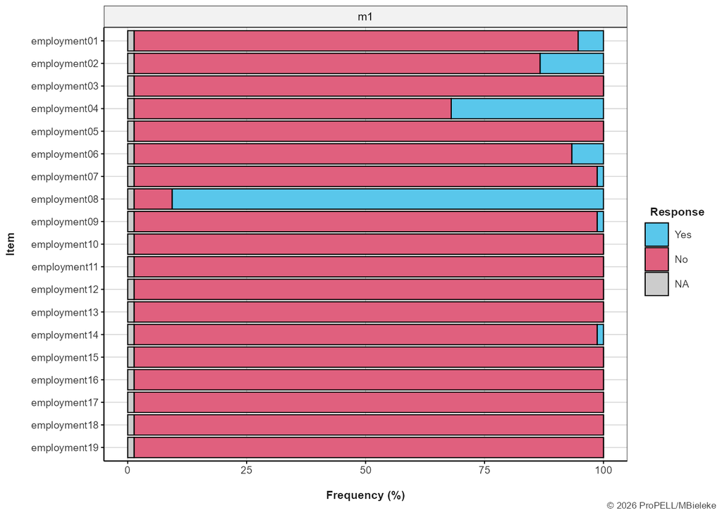

**Statistics**

| Variable | #Yes | %Yes | %Val Yes | #No | %No | %Val No | #Miss | %Miss |
| --- | --- | --- | --- | --- | --- | --- | --- | --- |
| **employment01** |  |  |  |  |  |  |  |  |
| m1 | 4 | 5.3 | 5.3 | 70 | 93.3 | 93.3 | 1 | 1.3 |
| **employment02** |  |  |  |  |  |  |  |  |
| m1 | 10 | 13.3 | 13.3 | 64 | 85.3 | 85.3 | 1 | 1.3 |
| **employment03** |  |  |  |  |  |  |  |  |
| m1 | 0 | 0.0 | 0.0 | 74 | 98.7 | 98.7 | 1 | 1.3 |
| **employment04** |  |  |  |  |  |  |  |  |
| m1 | 24 | 32.0 | 32.0 | 50 | 66.7 | 66.7 | 1 | 1.3 |
| **employment05** |  |  |  |  |  |  |  |  |
| m1 | 0 | 0.0 | 0.0 | 74 | 98.7 | 98.7 | 1 | 1.3 |
| **employment06** |  |  |  |  |  |  |  |  |
| m1 | 5 | 6.7 | 6.7 | 69 | 92.0 | 92.0 | 1 | 1.3 |
| **employment07** |  |  |  |  |  |  |  |  |
| m1 | 1 | 1.3 | 1.3 | 73 | 97.3 | 97.3 | 1 | 1.3 |
| **employment08** |  |  |  |  |  |  |  |  |
| m1 | 68 | 90.7 | 90.7 | 6 | 8.0 | 8.0 | 1 | 1.3 |
| **employment09** |  |  |  |  |  |  |  |  |
| m1 | 1 | 1.3 | 1.3 | 73 | 97.3 | 97.3 | 1 | 1.3 |
| **employment10** |  |  |  |  |  |  |  |  |
| m1 | 0 | 0.0 | 0.0 | 74 | 98.7 | 98.7 | 1 | 1.3 |
| **employment11** |  |  |  |  |  |  |  |  |
| m1 | 0 | 0.0 | 0.0 | 74 | 98.7 | 98.7 | 1 | 1.3 |
| **employment12** |  |  |  |  |  |  |  |  |
| m1 | 0 | 0.0 | 0.0 | 74 | 98.7 | 98.7 | 1 | 1.3 |
| **employment13** |  |  |  |  |  |  |  |  |
| m1 | 0 | 0.0 | 0.0 | 74 | 98.7 | 98.7 | 1 | 1.3 |
| **employment14** |  |  |  |  |  |  |  |  |
| m1 | 1 | 1.3 | 1.3 | 73 | 97.3 | 97.3 | 1 | 1.3 |
| **employment15** |  |  |  |  |  |  |  |  |
| m1 | 0 | 0.0 | 0.0 | 74 | 98.7 | 98.7 | 1 | 1.3 |
| **employment16** |  |  |  |  |  |  |  |  |
| m1 | 0 | 0.0 | 0.0 | 74 | 98.7 | 98.7 | 1 | 1.3 |
| **employment17** |  |  |  |  |  |  |  |  |
| m1 | 0 | 0.0 | 0.0 | 74 | 98.7 | 98.7 | 1 | 1.3 |
| **employment18** |  |  |  |  |  |  |  |  |
| m1 | 0 | 0.0 | 0.0 | 74 | 98.7 | 98.7 | 1 | 1.3 |
| **employment19** |  |  |  |  |  |  |  |  |
| m1 | 0 | 0.0 | 0.0 | 74 | 98.7 | 98.7 | 1 | 1.3 |

### Reason for participating in ProPELL

**Overview**

- **Variable Stem: `goal01`**
- **Time Points:** m1
- **Reference:** Custom item

**Details**

Which of the following goals are you primarily pursuing with your participation in the ProPELL project?

**Distribution**

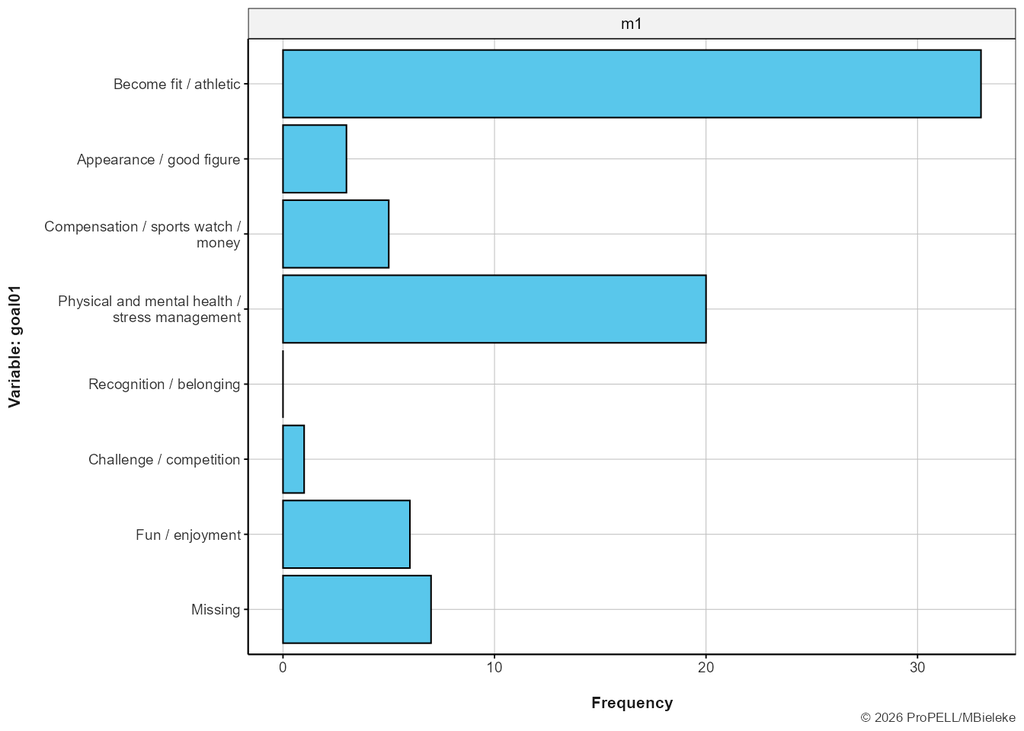

**Statistics**

| Answer | N | % | %Val |
| --- | --- | --- | --- |
| **Become fit / athletic** |  |  |  |
| m1 | 33 | 44.0 | 48.5 |
| **Appearance / good figure** |  |  |  |
| m1 | 3 | 4.0 | 4.4 |
| Compensation / sports watch / money |  |  |  |
| m1 | 5 | 6.7 | 7.3 |
| Physical and mental health / stress management |  |  |  |
| m1 | 20 | 26.7 | 29.4 |
| **Recognition / belonging** |  |  |  |
| m1 | 0 | 0.0 | 0.0 |
| **Challenge / competition** |  |  |  |
| m1 | 1 | 1.3 | 1.5 |
| **Fun / enjoyment** |  |  |  |
| m1 | 6 | 8.0 | 8.8 |
| **Missing** |  |  |  |
| m1 | 7 | 9.3 | --- |

### Reason for participating in ProPELL (other)

**Details**

Other

**Statistics**

[output not shown]

### Self-reported handedness

**Overview**

- **Variable Stem: `handedness`**
- **Time Points:** m1
- **Reference:** Custom item

**Details**

Are you left- or right-handed? Please consider whether you perform activities such as writing, throwing a ball, brushing your teeth, or cutting with a knife mainly or almost always with your left or your right hand.

**Distribution**

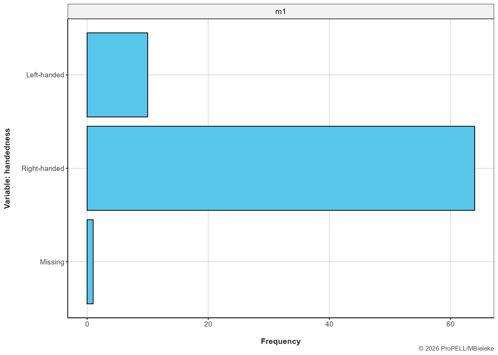

**Statistics**

| Answer | N | % | %Val |
| --- | --- | --- | --- |
| **Left-handed** |  |  |  |
| m1 | 10 | 13.3 | 13.5 |
| **Right-handed** |  |  |  |
| m1 | 64 | 85.3 | 86.5 |
| **Missing** |  |  |  |
| m1 | 1 | 1.3 | --- |

### Household composition (number of persons 18+ years)

**Overview**

- **Variable Stem: `hhadults`**
- **Time Points:** m1
- **Reference:** Custom item

**Details**

How many people in your household are 18 years or older?

**Distribution**

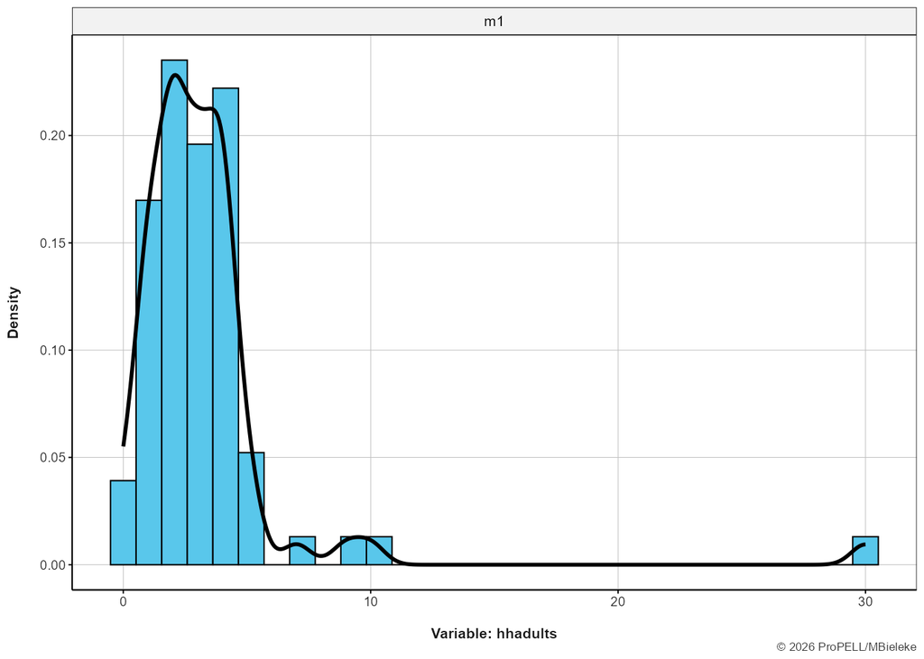

**Statistics**

| Time | N | % | %Val | Mean | SD | Min | Median | Max |
| --- | --- | --- | --- | --- | --- | --- | --- | --- |
| m1 | 75 | 74 | 98.67 | 3.22 | 3.62 | 0 | 3 | 30 |

### Partnership (living in same household)

**Overview**

- **Variable Stem: `hhpartner`**
- **Time Points:** m1
- **Reference:** Custom item

**Details**

Are you currently living in a partnership with someone from your household?

**Distribution**

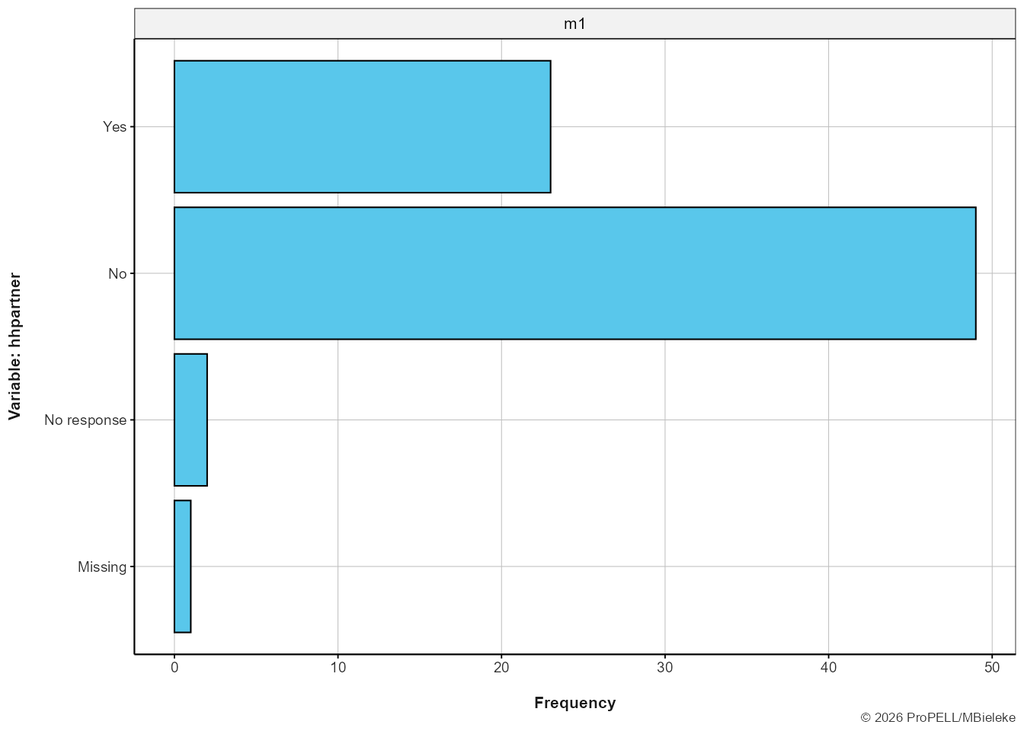

**Statistics**

| Answer | N | % | %Val |
| --- | --- | --- | --- |
| **Yes** |  |  |  |
| m1 | 23 | 30.7 | 31.1 |
| **No** |  |  |  |
| m1 | 49 | 65.3 | 66.2 |
| **No response** |  |  |  |
| m1 | 2 | 2.7 | 2.7 |
| **Missing** |  |  |  |
| m1 | 1 | 1.3 | --- |

### Household size (total number of persons)

**Overview**

- **Variable Stem: `hhsize`**
- **Time Points:** m1
- **Reference:** Custom item

**Details**

How many people live permanently in your household, including yourself? (This household includes all persons who live and manage the household together. Please also consider all children living in the household.)

**Distribution**

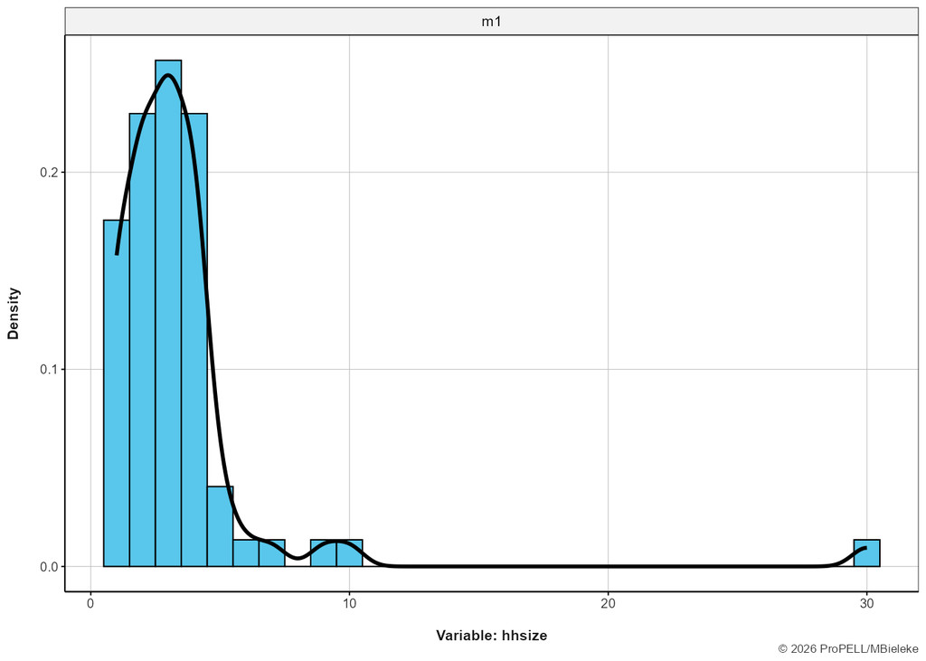

**Statistics**

| Time | N | % | %Val | Mean | SD | Min | Median | Max |
| --- | --- | --- | --- | --- | --- | --- | --- | --- |
| m1 | 75 | 74 | 98.67 | 3.36 | 3.56 | 1 | 3 | 30 |

### Average monthly net income

**Overview**

- **Variable Stem: `income`**
- **Time Points:** m1
- **Reference:** Custom item

**Details**

What is the amount of income that is available to you on average per month after taxes and social security contributions? The income includes wages, salary, income from self-employment, pension, public benefits, income from renting and leasing, assets, housing allowance, child benefits, and all other income.

**Distribution**

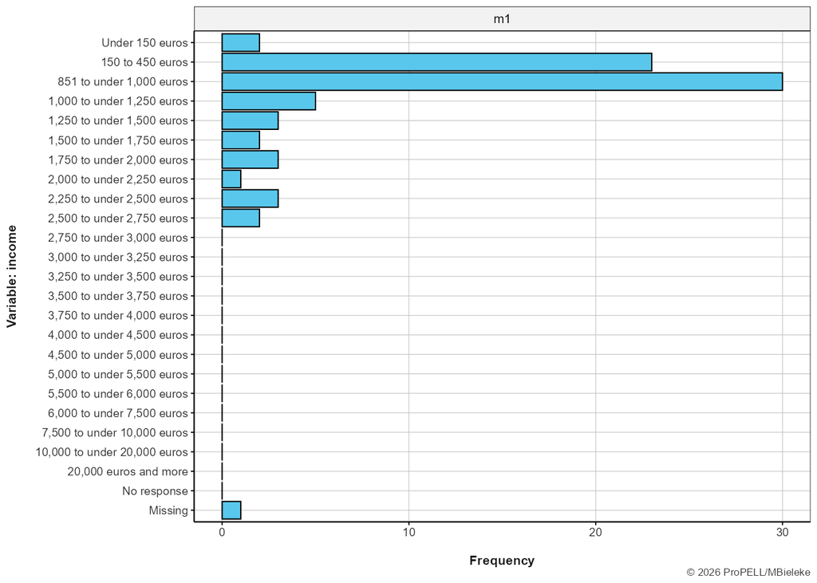

**Statistics**

| Answer | N | % | %Val |
| --- | --- | --- | --- |
| **Under 150 euros** |  |  |  |
| m1 | 2 | 2.7 | 2.7 |
| **150 to 450 euros** |  |  |  |
| m1 | 23 | 30.7 | 31.1 |
| **851 to under 1,000 euros** |  |  |  |
| m1 | 30 | 40.0 | 40.5 |
| **1,000 to under 1,250 euros** |  |  |  |
| m1 | 5 | 6.7 | 6.8 |
| **1,250 to under 1,500 euros** |  |  |  |
| m1 | 3 | 4.0 | 4.0 |
| **1,500 to under 1,750 euros** |  |  |  |
| m1 | 2 | 2.7 | 2.7 |
| **1,750 to under 2,000 euros** |  |  |  |
| m1 | 3 | 4.0 | 4.0 |
| **2,000 to under 2,250 euros** |  |  |  |
| m1 | 1 | 1.3 | 1.4 |
| **2,250 to under 2,500 euros** |  |  |  |
| m1 | 3 | 4.0 | 4.0 |
| **2,500 to under 2,750 euros** |  |  |  |
| m1 | 2 | 2.7 | 2.7 |
| **2,750 to under 3,000 euros** |  |  |  |
| m1 | 0 | 0.0 | 0.0 |
| **3,000 to under 3,250 euros** |  |  |  |
| m1 | 0 | 0.0 | 0.0 |
| **3,250 to under 3,500 euros** |  |  |  |
| m1 | 0 | 0.0 | 0.0 |
| **3,500 to under 3,750 euros** |  |  |  |
| m1 | 0 | 0.0 | 0.0 |
| **3,750 to under 4,000 euros** |  |  |  |
| m1 | 0 | 0.0 | 0.0 |
| **4,000 to under 4,500 euros** |  |  |  |
| m1 | 0 | 0.0 | 0.0 |
| **4,500 to under 5,000 euros** |  |  |  |
| m1 | 0 | 0.0 | 0.0 |
| **5,000 to under 5,500 euros** |  |  |  |
| m1 | 0 | 0.0 | 0.0 |
| **5,500 to under 6,000 euros** |  |  |  |
| m1 | 0 | 0.0 | 0.0 |
| **6,000 to under 7,500 euros** |  |  |  |
| m1 | 0 | 0.0 | 0.0 |
| **7,500 to under 10,000 euros** |  |  |  |
| m1 | 0 | 0.0 | 0.0 |
| **10,000 to under 20,000 euros** |  |  |  |
| m1 | 0 | 0.0 | 0.0 |
| **20,000 euros and more** |  |  |  |
| m1 | 0 | 0.0 | 0.0 |
| **No response** |  |  |  |
| m1 | 0 | 0.0 | 0.0 |
| **Missing** |  |  |  |
| m1 | 1 | 1.3 | --- |

### Marital status

**Overview**

- **Variable Stem: `marital`**
- **Time Points:** m1
- **Reference:** Custom item

**Details**

What is your marital status?

**Distribution**

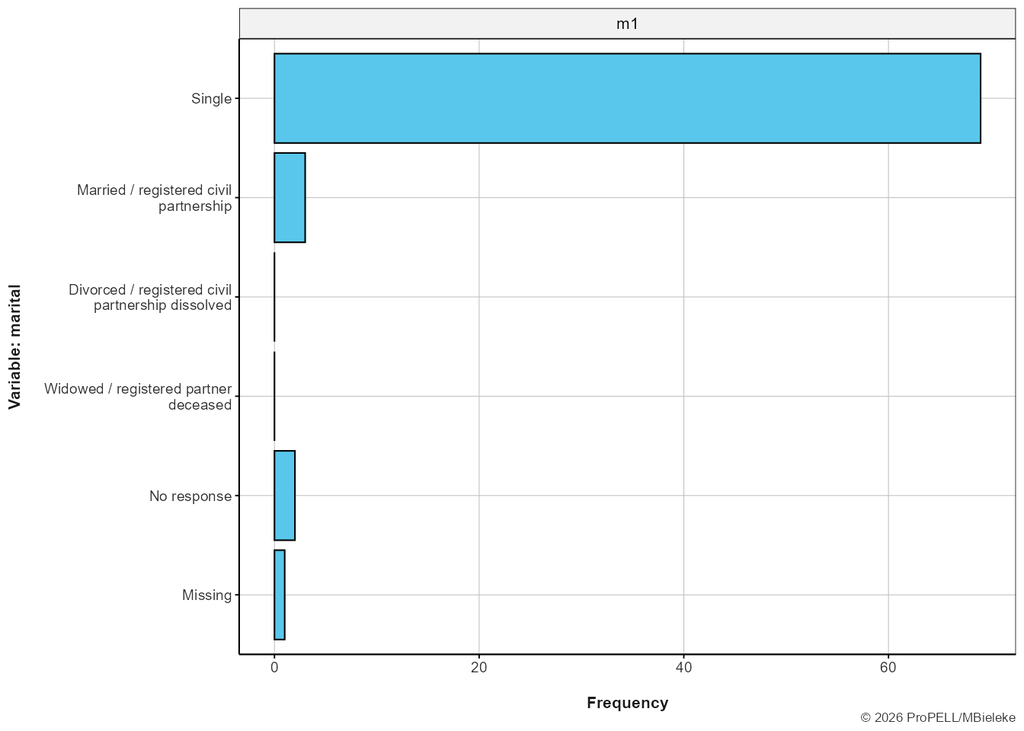

**Statistics**

| Answer | N | % | %Val |
| --- | --- | --- | --- |
| **Single** |  |  |  |
| m1 | 69 | 92.0 | 93.2 |
| Married / registered civil partnership |  |  |  |
| m1 | 3 | 4.0 | 4.0 |
| Divorced / registered civil partnership dissolved |  |  |  |
| m1 | 0 | 0.0 | 0.0 |
| Widowed / registered partner deceased |  |  |  |
| m1 | 0 | 0.0 | 0.0 |
| **No response** |  |  |  |
| m1 | 2 | 2.7 | 2.7 |
| **Missing** |  |  |  |
| m1 | 1 | 1.3 | --- |

### >100k residence <15 years

**Overview**

- **Variable Stem: `pastresid01`**
- **Time Points:** m1
- **Reference:** Custom item

**Details**

Up to the age of 15, how many years did you live in cities with more than 100,000 inhabitants?

**Distribution**

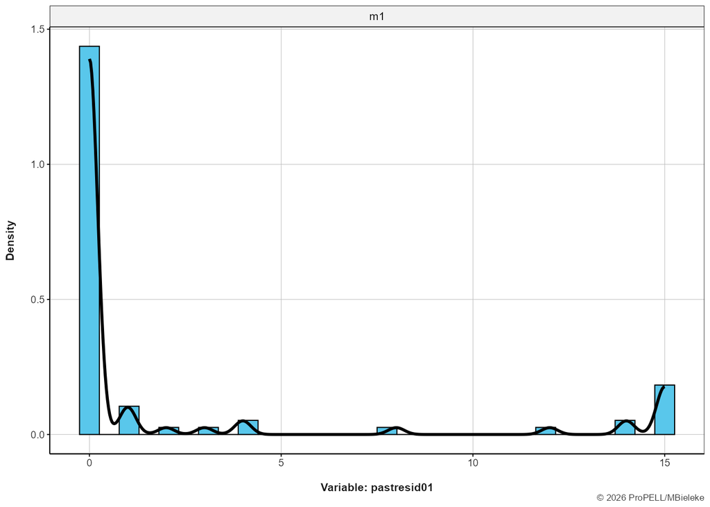

**Statistics**

| Time | N | % | %Val | Mean | SD | Min | Median | Max |
| --- | --- | --- | --- | --- | --- | --- | --- | --- |
| m1 | 75 | 74 | 98.67 | 2.3 | 5.01 | 0 | 0 | 15 |

### 10-100k residence <15 years

**Overview**

- **Variable Stem: `pastresid02`**
- **Time Points:** m1
- **Reference:** Custom item

**Details**

Up to the age of 15, how many years did you live in small towns with 10,000 to 100,000 inhabitants?

**Distribution**

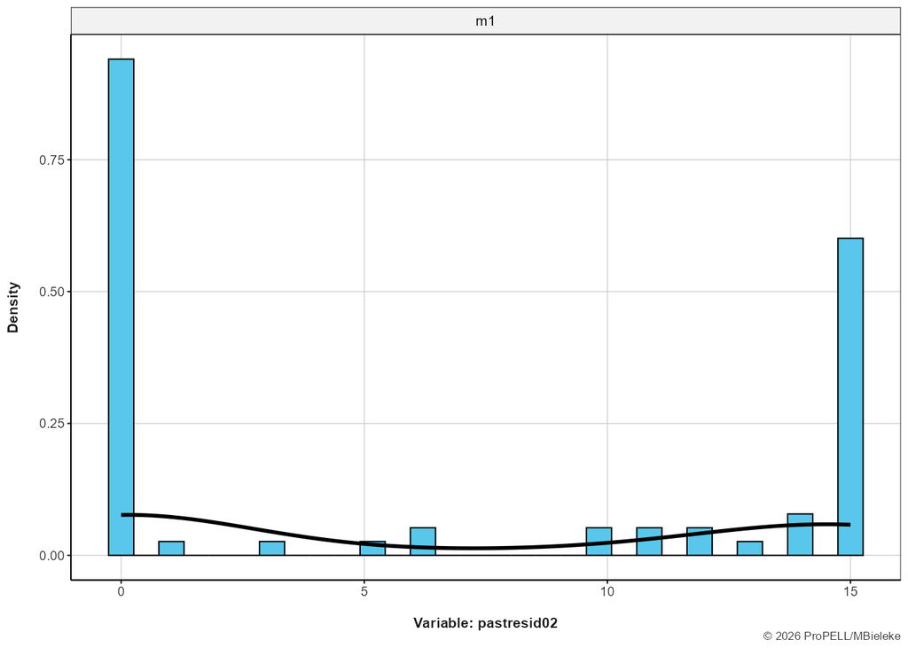

**Statistics**

| Time | N | % | %Val | Mean | SD | Min | Median | Max |
| --- | --- | --- | --- | --- | --- | --- | --- | --- |
| m1 | 75 | 74 | 98.67 | 6.58 | 6.99 | 0 | 2 | 15 |

### Rural residence <15 years

**Overview**

- **Variable Stem: `pastresid03`**
- **Time Points:** m1
- **Reference:** Custom item

**Details**

Up to the age of 15, how many years did you live in rural areas?

**Distribution**

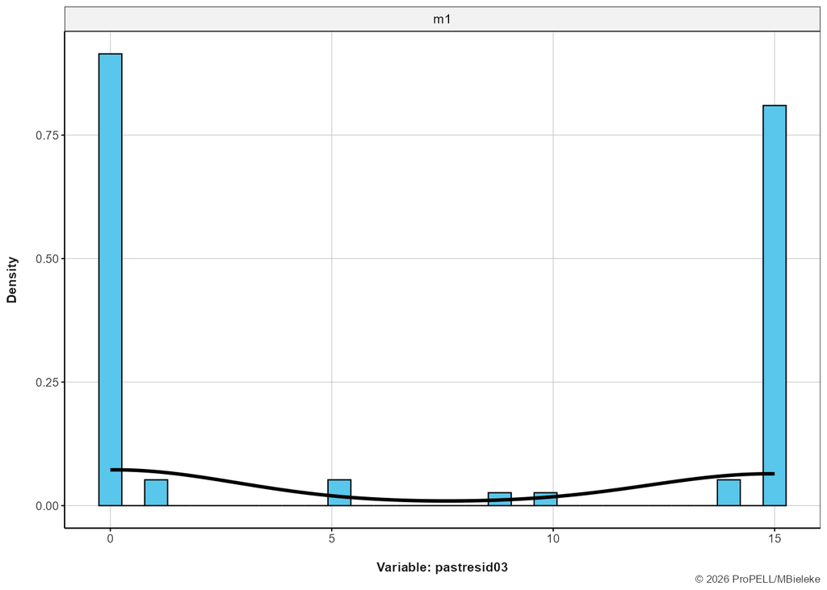

**Statistics**

| Time | N | % | %Val | Mean | SD | Min | Median | Max |
| --- | --- | --- | --- | --- | --- | --- | --- | --- |
| m1 | 75 | 74 | 98.67 | 7.08 | 7.3 | 0 | 3 | 15 |

### Study subjects and current semesters

**Details**

Which fields of study are you enrolled in, and which semester are you currently in for each? Please list all fields and indicate the number of subject-specific semesters in parentheses.

**Statistics**

[output not shown]

# State Surveys

### Use of hormonal contraceptives or the pill

**Overview**

- **Variable Stem: `contraceptiva`**
- **Time Points:** w02, w12, w21
- **Reference:** Custom item

**Note:** This question was administered to women only.

**Details**

Are you currently taking hormonal contraceptives / the pill?

**Distribution**

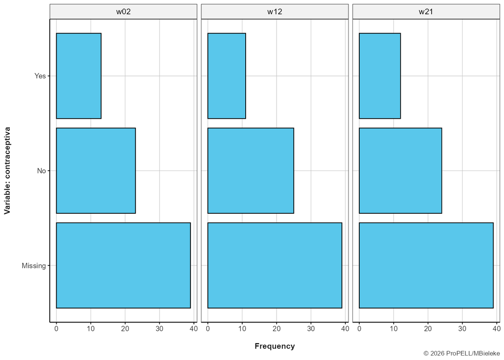

**Statistics**

| Answer | N | % | %Val |
| --- | --- | --- | --- |
| **Yes** |  |  |  |
| w02 | 13 | 17.3 | 36.1 |
| w12 | 11 | 14.7 | 30.6 |
| w21 | 12 | 16.0 | 33.3 |
| **No** |  |  |  |
| w02 | 23 | 30.7 | 63.9 |
| w12 | 25 | 33.3 | 69.4 |
| w21 | 24 | 32.0 | 66.7 |
| **Missing** |  |  |  |
| w02 | 39 | 52.0 | --- |
| w12 | 39 | 52.0 | --- |
| w21 | 39 | 52.0 | --- |

**Overview**

- **Variable Stem: `cyclelength`**
- **Time Points:** w02, w12, w21
- **Reference:** Custom item

**Note:** This question was administered to women only.

**Details**

On average, what is the interval between two menstrual periods (from the first day of bleeding to the first day of the next bleeding)?

**Distribution**

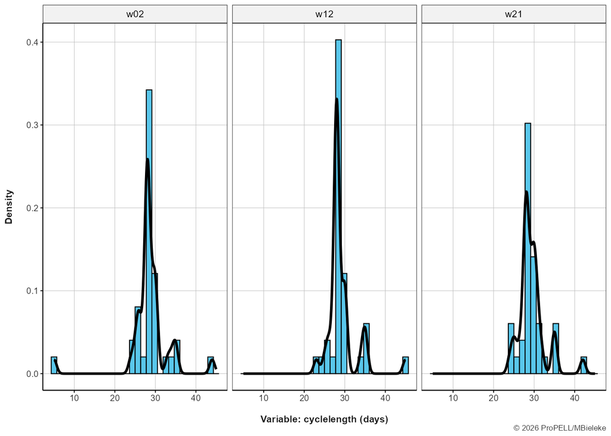

**Statistics**

| Time | N | % | %Val | Mean | SD | Min | Median | Max |
| --- | --- | --- | --- | --- | --- | --- | --- | --- |
| w02 | 75 | 36 | 48 | 28.46 | 5.37 | 5 | 28 | 44 |
| w12 | 75 | 36 | 48 | 29.22 | 3.73 | 23 | 28 | 45 |
| w21 | 75 | 36 | 48 | 29.44 | 3.31 | 24 | 29 | 42 |

### Physical exertion in the last 7-10 days

**Overview**

- **Variable Stem: `effort`**
- **Time Points:** w05, w07, w09, w11, w14, w16, w18, w20
- **Reference:** Custom item

**Details**

Think back to the past 7–10 days. Were there moments when you exerted yourself physically?

**Distribution**

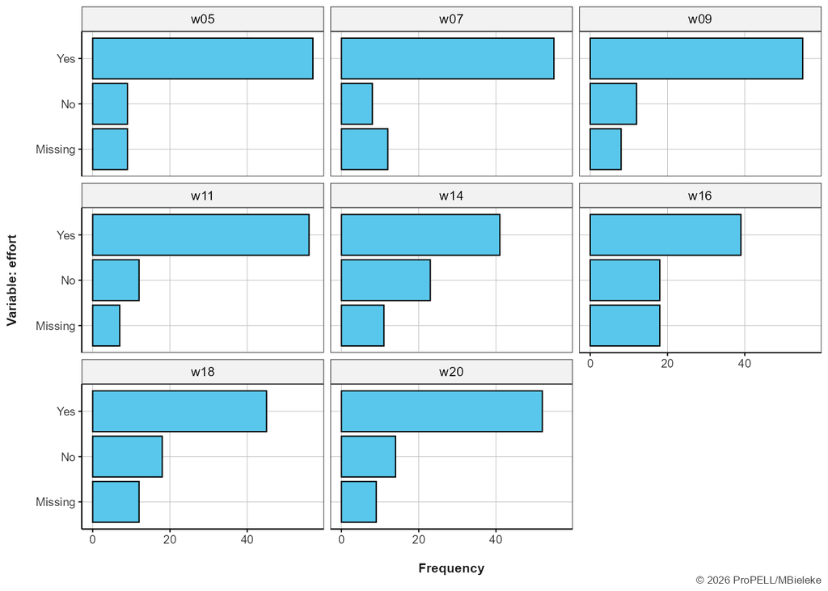

**Statistics**

| Answer | N | % | %Val |
| --- | --- | --- | --- |
| **Yes** |  |  |  |
| w05 | 57 | 76.0 | 86.4 |
| w07 | 55 | 73.3 | 87.3 |
| w09 | 55 | 73.3 | 82.1 |
| w11 | 56 | 74.7 | 82.3 |
| w14 | 41 | 54.7 | 64.1 |
| w16 | 39 | 52.0 | 68.4 |
| w18 | 45 | 60.0 | 71.4 |
| w20 | 52 | 69.3 | 78.8 |
| **No** |  |  |  |
| w05 | 9 | 12.0 | 13.6 |
| w07 | 8 | 10.7 | 12.7 |
| w09 | 12 | 16.0 | 17.9 |
| w11 | 12 | 16.0 | 17.6 |
| w14 | 23 | 30.7 | 35.9 |
| w16 | 18 | 24.0 | 31.6 |
| w18 | 18 | 24.0 | 28.6 |
| w20 | 14 | 18.7 | 21.2 |
| **Missing** |  |  |  |
| w05 | 9 | 12.0 | --- |
| w07 | 12 | 16.0 | --- |
| w09 | 8 | 10.7 | --- |
| w11 | 7 | 9.3 | --- |
| w14 | 11 | 14.7 | --- |
| w16 | 18 | 24.0 | --- |
| w18 | 12 | 16.0 | --- |
| w20 | 9 | 12.0 | --- |

### German Single-Item Self-Esteem (G-SISE) Scale

**Overview**

- **Variable Stem: `esteem`**
- **Time Points:** w05, w07, w09, w11, w14, w16, w18, w20
- **Reference:** Brailovskaia & Margraf (2020)

**Details**

Please indicate to what extent the following statement applies to you: “I have high self-esteem.”

**Distribution**

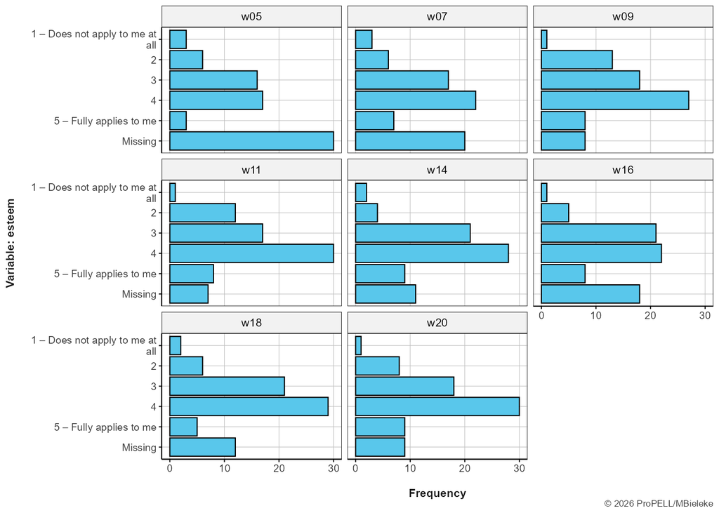

**Statistics**

| Answer | N | % | %Val |
| --- | --- | --- | --- |
| 1 – Does not apply to me at all |  |  |  |
| w05 | 3 | 4.0 | 6.7 |
| w07 | 3 | 4.0 | 5.4 |
| w09 | 1 | 1.3 | 1.5 |
| w11 | 1 | 1.3 | 1.5 |
| w14 | 2 | 2.7 | 3.1 |
| w16 | 1 | 1.3 | 1.8 |
| w18 | 2 | 2.7 | 3.2 |
| w20 | 1 | 1.3 | 1.5 |
| **2** |  |  |  |
| w05 | 6 | 8.0 | 13.3 |
| w07 | 6 | 8.0 | 10.9 |
| w09 | 13 | 17.3 | 19.4 |
| w11 | 12 | 16.0 | 17.6 |
| w14 | 4 | 5.3 | 6.2 |
| w16 | 5 | 6.7 | 8.8 |
| w18 | 6 | 8.0 | 9.5 |
| w20 | 8 | 10.7 | 12.1 |
| **3** |  |  |  |
| w05 | 16 | 21.3 | 35.6 |
| w07 | 17 | 22.7 | 30.9 |
| w09 | 18 | 24.0 | 26.9 |
| w11 | 17 | 22.7 | 25.0 |
| w14 | 21 | 28.0 | 32.8 |
| w16 | 21 | 28.0 | 36.8 |
| w18 | 21 | 28.0 | 33.3 |
| w20 | 18 | 24.0 | 27.3 |
| **4** |  |  |  |
| w05 | 17 | 22.7 | 37.8 |
| w07 | 22 | 29.3 | 40.0 |
| w09 | 27 | 36.0 | 40.3 |
| w11 | 30 | 40.0 | 44.1 |
| w14 | 28 | 37.3 | 43.8 |
| w16 | 22 | 29.3 | 38.6 |
| w18 | 29 | 38.7 | 46.0 |
| w20 | 30 | 40.0 | 45.5 |
| **5 – Fully applies to me** |  |  |  |
| w05 | 3 | 4.0 | 6.7 |
| w07 | 7 | 9.3 | 12.7 |
| w09 | 8 | 10.7 | 11.9 |
| w11 | 8 | 10.7 | 11.8 |
| w14 | 9 | 12.0 | 14.1 |
| w16 | 8 | 10.7 | 14.0 |
| w18 | 5 | 6.7 | 7.9 |
| w20 | 9 | 12.0 | 13.6 |
| **Missing** |  |  |  |
| w05 | 30 | 40.0 | --- |
| w07 | 20 | 26.7 | --- |
| w09 | 8 | 10.7 | --- |
| w11 | 7 | 9.3 | --- |
| w14 | 11 | 14.7 | --- |
| w16 | 18 | 24.0 | --- |
| w18 | 12 | 16.0 | --- |
| w20 | 9 | 12.0 | --- |

### IPAQ-SF 7 days - MET minutes

**Overview**

- **Variable Stem: `ipaq7`**
- **Time Points:** w02, w13
- **Reference:** Craig et al. (2003)

**Note:** The IPAQ has additionally been assessed in two state questionnaire accompanying the amubulatory assessments.

**Details**

We are interested in finding out what types of physical activities you perform in your daily life. The following questions refer to the time you spent on physical activity during the last 7 days. Please answer all questions (even if you do not consider yourself an active person). Please include activities as part of your work, in the house and garden, to get from one place to another, and in your leisure time for recreation, fitness, and sport. In the following, think about all your strenuous and moderate activities during the past 7 days. Strenuous activities refer to activities that require hard physical effort and make you breathe much harder than normal. Moderate activities refer to activities that require moderate physical effort and make you breathe somewhat harder than normal.

**Distribution**

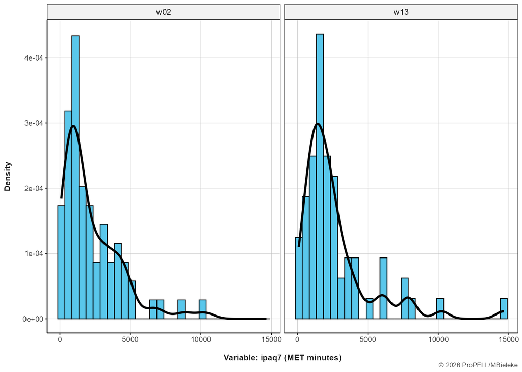

**Statistics**

| Time | N | % | %Val | Mean | SD | Min | Median | Max |
| --- | --- | --- | --- | --- | --- | --- | --- | --- |
| w02 | 75 | 69 | 92.00 | 2209.38 | 2053.61 | 99 | 1426 | 10288 |
| w13 | 75 | 64 | 85.33 | 2677.56 | 2583.57 | 99 | 1935 | 14640 |